# Part 3 - Numpy and Pandas

## Numpy

Numpy is Numerical Python and the most basic and powerful computational package in Python.  
In order to use numpy functionality, one needs to import Numpy module.

```python
## import numpy
import numpy as np
```

### How to create Numpy Array

Array is a fast, flexible container for large data sets in Python.  
Array is also referred as nparray, N-dimensional array.

```python
## Creating Numpy - one dimensional array
numpy1 = np.array([1,2,3,4])
print(numpy1)
print(type(numpy1))
print(numpy1.shape)
```

```
[1 2 3 4]
<class 'numpy.ndarray'>
(4,)
```

```python
## Creating Numpy - two dimensional array
numpy2 = np.array([[1,2,3,4], [5,6,7,8]])
print(numpy2)
print(type(numpy2))
print(numpy2.shape)
```

```
[[1 2 3 4]
 [5 6 7 8]]
<class 'numpy.ndarray'>
(2, 4)
```

```python
## Creating Numpy - three dimensional array
numpy3 = np.zeros((2,2,2))  # 2 by 2 by 2 array with zeros assigned
print(numpy3)
print(type(numpy3))
print(numpy3.shape)
```

```
[[[0. 0.]
  [0. 0.]]

 [[0. 0.]
  [0. 0.]]]
<class 'numpy.ndarray'>
(2, 2, 2)
```

```python
## Creating Numpy with floating type
numpy4 = np.array([1,2,3,4], dtype=np.float64)
print(numpy4)
print(type(numpy4))
print(numpy4.shape)
print(numpy4.dtype)

## Creating Numpy with integer type
numpy5 = np.array([1,2,3,4], dtype=np.int16)
print(numpy5)
print(type(numpy5))
print(numpy5.shape)
print(numpy5.dtype)
```

```
[1. 2. 3. 4.]
<class 'numpy.ndarray'>
(4,)
float64
[1 2 3 4]
<class 'numpy.ndarray'>
(4,)
int16
```

### Numpy Array Indexing and Slicing

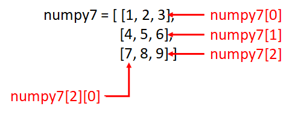

```python
## Indexing and slicing of numpy
numpy6 = np.array([0,1,2,3,4,5,6,7,8,9])
print(numpy6)
print("index 0 and 6", numpy6[0] , numpy6[6])
print("slicing up to index 4: " , numpy6[:4])
print("slicing from index 4 to 8: " , numpy6[4:8])
```

```
[0 1 2 3 4 5 6 7 8 9]
index 0 and 6 0 6
slicing up to index 4:  [0 1 2 3]
slicing from index 4 to 8:  [4 5 6 7]
```

```python
## Two Dimentional Array
numpy7 = np.array([[1,2,3],[4,5,6],[7,8,9]]) # 2 dimension
print(numpy7)
print("Shape of array: ", numpy7.shape)
print("index 1: " , numpy7[1])
print("index 1 2: " , numpy7[1][2])
```

```
[[1 2 3]
 [4 5 6]
 [7 8 9]]
Shape of array:  (3, 3)
index 1:  [4 5 6]
index 1 2:  6
```

### Reshape Numpy Array

```python
## Reshaping array ursing reshape method
numpy6 = np.array([1,2,3,4,5,6,7,8,9])
numpy8 = numpy6.reshape(3,3)  ## reshape method
print("Original array: ", numpy6)
print("Reshaped array: \n", numpy8)
print("Shape of array: ", numpy8.shape)
print("index 1: " , numpy8[1])
print("index 2 & 1: " , numpy8[2][1])
```

```
Original array:  [1 2 3 4 5 6 7 8 9]
Reshaped array:
 [[1 2 3]
 [4 5 6]
 [7 8 9]]
Shape of array:  (3, 3)
index 1:  [4 5 6]
index 2 & 1:  8
```

```python
## Transposing array
numpy6 = np.array([0,1,2,3,4,5,6,7,8,9])
numpy9 = numpy6.reshape(5,2)  ## reshape method
numpy10 = numpy9.T
print("Original array: ", numpy6)
print("Reshaped array: \n", numpy9)
print("Shape of array: ", numpy9.shape)
print("Transposed array: \n", numpy10)
print("Shape of array: ", numpy10.shape)
```

```
Original array:  [0 1 2 3 4 5 6 7 8 9]
Reshaped array:
 [[0 1]
 [2 3]
 [4 5]
 [6 7]
 [8 9]]
Shape of array:  (5, 2)
Transposed array:
 [[0 2 4 6 8]
 [1 3 5 7 9]]
Shape of array:  (2, 5)
```

### Numpy Array Calculation

```python
## Array Calculation
## addition
numpy11 = np.array([1,2,3,4])
numpy12 = numpy11 + numpy11
print(numpy12)
```

```
[2 4 6 8]
```

```python
numpy13 = np.array([2,2])
numpy14 = numpy11 + numpy13  ## different shapes of array can't be added - Error Message
```

```
---------------------------------------------------------------------------
ValueError                                Traceback (most recent call last)
<ipython-input-12-2157674173ab> in <module>
      1 numpy13 = np.array([2,2])
----> 2 numpy14 = numpy11 + numpy13  ## different shapes of array can't be added - Error Message

ValueError: operands could not be broadcast together with shapes (4,) (2,)
```

```python
## Array Calculation
## multiplication
numpy11 = np.array([1,2,3,4])
numpy15 = numpy11 *2
print(numpy11, " is multiplied by 2, then the result: ", numpy15)

numpy16 = np.array([2,2, 1, 2])
numpy17 = numpy11 * numpy16
print(numpy11, " times ", numpy16, " is ",numpy17)

numpy18 = np.array([1,2])
```

```
[1 2 3 4]  is multiplied by 2, then the result:  [2 4 6 8]
[1 2 3 4]  times  [2 2 1 2]  is  [2 4 3 8]
```

```python
numpy19 = numpy11 * numpy18  ## can't be multiplied by the different shapes - Error Message
```

```
---------------------------------------------------------------------------
ValueError                                Traceback (most recent call last)
<ipython-input-14-5807205ae5b6> in <module>
----> 1 numpy19 = numpy11 * numpy18  ## can't be multiplied by the different shapes - Error Message

ValueError: operands could not be broadcast together with shapes (4,) (2,)
```

```python
## Simple mathematical funtions and method in numpy
numpy20 = np.random.randn(4,5)  ## create randomly distributed 4 by 5 array
print(numpy20)

print("mean values of array : ", numpy20.mean())  # mean values using mean method of numpy20 instance
print("mean values of array : ", np.mean(numpy20))  # mean values using function of np.mean
print("max & min values of array : ", numpy20.max(), numpy20.min())  # max and min values using method of numpy20 instance
```

```
[[-0.52109731 -0.09480359  0.54646922  0.41089639 -0.24585963]
 [ 0.20027677  1.29326286  1.36686165 -0.5005697  -0.00185125]
 [-1.42895859 -0.1436207   1.62506731 -0.06330866  1.81797734]
 [ 0.37088435 -0.73922968  0.10645576  0.97056232 -0.64317094]]
mean values of array :  0.21631219547102062
mean values of array :  0.21631219547102062
max & min values of array :  1.8179773449060768 -1.4289585904001236
```

Mathematical calculation depending on Axis.  
Axis = 0 does the mathematical calculation by columns, so 3 by 4 array create 4 results.  
Axis = 1 does the mathematical calculation by rows, so 3 by 4 array create 3 results.

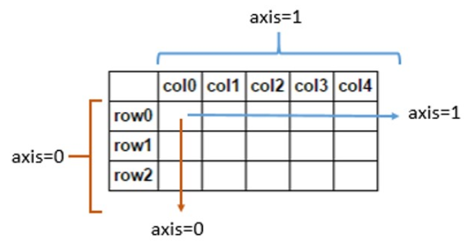

```python
## Mathematical calcualtion using axis
print(numpy20)
print("\nmean values of array on axis 0 : ", numpy20.mean(axis=0))
print("mean values of array on axis 1 : ", numpy20.mean(axis=1))
print("\nsum values of array : ", numpy20.sum())
print("sum values of array on axis 0 : ", numpy20.sum(axis=0))
print("sum values of array on axis 1 : ", numpy20.sum(axis=1))
print("mean values of array on axis 1 : ", numpy20.sum(axis=1)/5)
```

```
[[-0.52109731 -0.09480359  0.54646922  0.41089639 -0.24585963]
 [ 0.20027677  1.29326286  1.36686165 -0.5005697  -0.00185125]
 [-1.42895859 -0.1436207   1.62506731 -0.06330866  1.81797734]
 [ 0.37088435 -0.73922968  0.10645576  0.97056232 -0.64317094]]

mean values of array on axis 0 :  [-0.3447237   0.07890222  0.91121348  0.20439509  0.23177388]
mean values of array on axis 1 :  [0.01912102 0.47159607 0.36143134 0.01310036]

sum values of array :  4.326243909420413
sum values of array on axis 0 :  [-1.37889478  0.31560889  3.64485393  0.81758035  0.92709552]
sum values of array on axis 1 :  [0.09560508 2.35798033 1.8071567  0.0655018 ]
mean values of array on axis 1 :  [0.01912102 0.47159607 0.36143134 0.01310036]
```

### Recap : Numpy Array basic structure

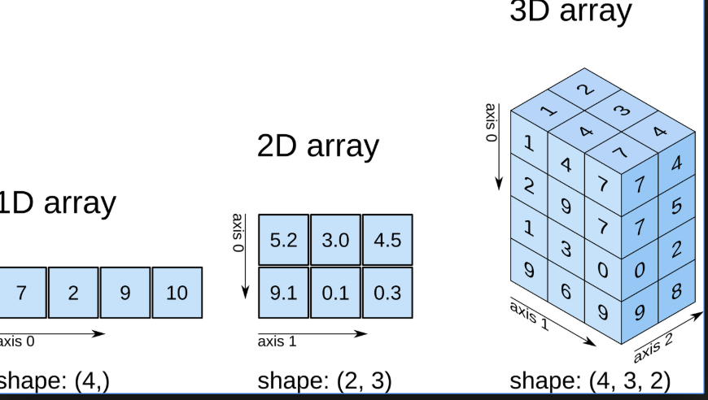

## Pandas

Pandas is the primary data structures for many analysis and it provides data manipulation tools designed to make data analyst fast and easy in Python.  
Its structure is row and column based table structure.  
It provides merge and other relational operations found in relational database.  
It has two data structures

- Series
- DataFrame

```python
## import pandas module
from pandas import Series, DataFrame
import pandas as pd
```

### Series

A series is one-dimentional array-like object.  
A series is considered as individual column of dataframe.  
In SAS, a series is similar to one row or one column.

```python
series1 = Series([1,2,3,4])
print(series1)
print(type(series1))
print(series1.shape)
```

```
0    1
1    2
2    3
3    4
dtype: int64
<class 'pandas.core.series.Series'>
(4,)
```

```python
## creating Series using dictionary
raw1 = {'subjid': '01-001','siteid': '01','sex': 'M', 'age': 29} ## dicionary
series2 = Series(raw1)
print(series2)
print("Type of series : ", type(series2))
print("Shape of Series : ", series2.shape)
print("value of age : ", series2.age)
print("value of age : ", series2['age'])
```

```
subjid    01-001
siteid        01
sex            M
age           29
dtype: object
Type of series :  <class 'pandas.core.series.Series'>
Shape of Series :  (4,)
value of age :  29
value of age :  29
```

Series has two componets

- index
- values

Series is very similar to dictionary and its main difference is Series uses 'index' while Dictionary uses 'key'.

```python
print("Series1 index: ", series1.index)
print("Series1 value: ", series1.values)

print("Series2 index: ", series2.index)
print("Series2 value: ", series2.values)
```

```
Series1 index:  RangeIndex(start=0, stop=4, step=1)
Series1 value:  [1 2 3 4]
Series2 index:  Index(['subjid', 'siteid', 'sex', 'age'], dtype='object')
Series2 value:  ['01-001' '01' 'M' 29]
```

## DataFrame

A DataFrame is a tabular, spreadsheet-like data structure whose columns have different value type (numeric, string, boolean and etc)  
A DataFrame has row and column index.

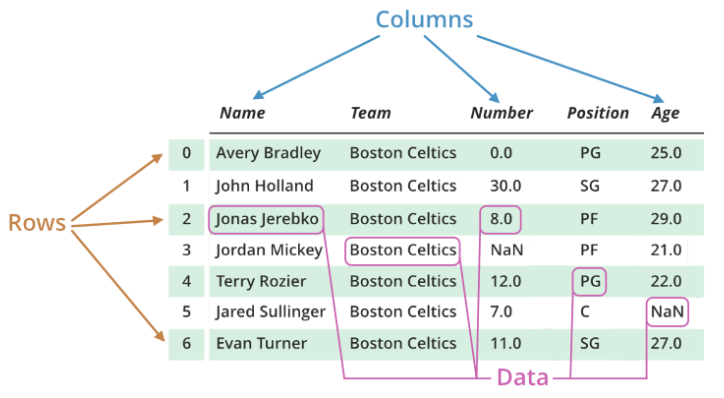

### How to create DataFrame

```python
## creating dataframe from dictionaries
raw = {'subjid': ['01-001', '01-002', '01-003', '02-001'],
      'siteid': ['01','01','01','02'],
      'sex': ['M','F','F','M'],
      'age': [29, 40, 35, 56]} ## dicionary
df1 = DataFrame(raw)
print("DataFrame :\n", df1)
print("Data Type: ", type(df1))
```

```
DataFrame :
    subjid siteid sex  age
0  01-001     01   M   29
1  01-002     01   F   40
2  01-003     01   F   35
3  02-001     02   M   56
Data Type:  <class 'pandas.core.frame.DataFrame'>
```

### Extracting column and row from DataFrame

```python
## Extracting column
series11 = df1.sex    ## extract sex variable
series12 = df1['sex'] ## extract sex variable
print("Sex column from dataframe:\n", series11)
print(type(series11))
print(series12)  ## same result
```

```
Sex column from dataframe:
 0    M
1    F
2    F
3    M
Name: sex, dtype: object
<class 'pandas.core.series.Series'>
0    M
1    F
2    F
3    M
Name: sex, dtype: object
```

```python
## extracting row
series13 = df1.loc[0]    ## extract first row
print("First column from dataframe:\n", series13)
print(type(series13))
```

```
First column from dataframe:
 subjid    01-001
siteid        01
sex            M
age           29
Name: 0, dtype: object
<class 'pandas.core.series.Series'>
```

### Extract the value from DataFrame

```python
## extracting the value from dataframe
print(df1)
val1 = df1.loc[0,'sex']  ## first position - row, second position - column
print("value of index 0 and column 'sex': ", val1)
print(type(val1))
```

```
   subjid siteid sex  age
0  01-001     01   M   29
1  01-002     01   F   40
2  01-003     01   F   35
3  02-001     02   M   56
value of index 0 and column 'sex':  M
<class 'str'>
```

### Metadata for DataFrame

```python
## Understanding about data
print("Property of dataframe: \n", df1.dtypes)  ## property of columns
print("Columns of dataframe: ", df1.columns) ## list columns
print("Index of dataframe: ", df1.index.values.tolist()) ## list row
print("Shaep of dataframe: ", df1.shape) ## shape
print("Dimension of dataframe: ", df1.ndim)  ## dimension
```

```
Property of dataframe:
 subjid    object
siteid    object
sex       object
age        int64
dtype: object
Columns of dataframe:  Index(['subjid', 'siteid', 'sex', 'age'], dtype='object')
Index of dataframe:  [0, 1, 2, 3]
Shaep of dataframe:  (4, 4)
Dimension of dataframe:  2
```

```python
df1.describe() ## describe the numeric data
```

|  | age |
| --- | --- |
| count | 4.000000 |
| mean | 40.000000 |
| std | 11.575837 |
| min | 29.000000 |
| 25% | 33.500000 |
| 50% | 37.500000 |
| 75% | 44.000000 |
| max | 56.000000 |

### Data Manipulation in DataFrame

```python
## Adding variables
df1['country'] = 'USA'
print(df1)
```

```
   subjid siteid sex  age country
0  01-001     01   M   29     USA
1  01-002     01   F   40     USA
2  01-003     01   F   35     USA
3  02-001     02   M   56     USA
```

```python
## sorting data using sort_values method
df1 = df1.sort_values(by=['age', 'sex'])  ## by age and sex
print(df1)

df1 = df1.sort_values(by=['sex', 'age'], ascending=False) ## sortying in descending order
print(df1)

df1 = df1.sort_values(by=['sex','age'], ascending=[False, True]) ## sortying in descending and ascending order
print(df1)
```

[output not shown]

```python
## Dataframe can have different types of elements
df2 = DataFrame({'col1': ['a','b', 3, 4], 'col2' : ['c','d', np.nan, True]})
print(df2)

print("\nProperty of dataframe: \n", df2.dtypes)  ## property of columns
print("The type of ", df2.loc[0,'col1'], " is " ,type(df2.loc[0,'col1']))  # string type
print("The type of ", df2.loc[2,'col1'], " is " ,type(df2.loc[2,'col1']))  # integer type
print("The type of ", df2.loc[2,'col2'], " is " ,type(df2.loc[2,'col2']))  # np.nan is float type
print("The type of ", df2.loc[3,'col2'], " is " ,type(df2.loc[3,'col2']))  # Boolean type
```

```
  col1  col2
0    a     c
1    b     d
2    3   NaN
3    4  True

Property of dataframe:
 col1    object
col2    object
dtype: object
The type of  a  is  <class 'str'>
The type of  3  is  <class 'int'>
The type of  nan  is  <class 'float'>
The type of  True  is  <class 'bool'>
```

### Remove a column or row of DataFrame

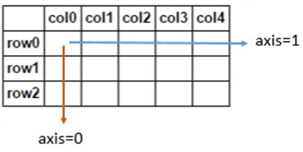

```python
## removing columns
df3 = df2.drop(['col2'], axis=1)  ## drop column
print("new dataframe -col2 deleted : \n", df3)

## removing rows (index)
df4 = df2.drop([2], axis=0)  ## drop row
print("new dataframe -index 2 deleted : \n", df4)
```

```
new dataframe -col2 deleted :
   col1
0    a
1    b
2    3
3    4
new dataframe -index 2 deleted :
   col1  col2
0    a     c
1    b     d
3    4  True
```

### Filter data

The basic structure of dataframe by index and columns

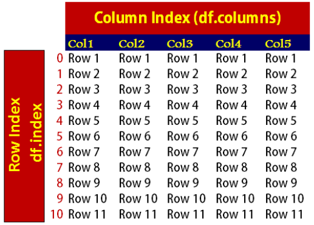

Any data manipulation such as selecting and filtering will be based on index and columns.  
For example, filtering of data from dataframe needs codes of df.iloc[[index,columns]]. Index goes first and columns next just like axis=0 and axis=1.

```python
df5 = DataFrame(raw)
print("Original dataframe: \n", df5)

## filtering by index - row
df6 = df5.loc[[1,3]] ## index 1 and 3
print("\nNew dataframe of index 1 and 3: \n",df6)

## filtering by columns
df7 = df5.loc[ :,['subjid','diabp']] ## columns subjid and diabp
print("\nNew dataframe of columns of subjid and diabp: \n",df7)
df7 = df5[['subjid','diabp']] ## columns subjid and diabp
print("\nNew dataframe of columns of subjid and diabp: \n",df7)

## filtering by columns and rows
df8 = df5.loc[[1,3],['sysbp','diabp']] ## index 1 and 3 & columns subjid and diabp
print("\nNew dataframe of index 1 and 3 and columns, subjid and diabp: \n",df8)
```

[output not shown]

```python
## using boolean to filter data
df1.sort_values(by=['subjid'], inplace=True)
print("Original                   : \n", df1, "\n")

df9 = df1[[False, True, False, True]]  # row number 0, 1, ,2, 3
print("New dataframe using boolean: \n", df9)  ## example of boolean filtering

print("\nBoolean result of condition : \n", df1.age > 35)
print(type(df1.age > 35))
df10 = df1[df1.age > 35]
print("\nNew dataframe using boolean: \n", df10)  ## only keep the index of age > 35
```

[output not shown]

```python
## Null value in dataframe
raw2 = {'subjid': ['01-001', '01-002', '01-003', '02-001'],
      'siteid': ['01','01','01',np.NaN],
      'sex': ['M','F','F','M'],
      'age': [29, 40, 35, 56]} ## dicionary
df12 = DataFrame(raw2)
print(df12)
df12.siteid.isnull()
print("\nnull value : ", df12.siteid[3], ". Its type : ", type(df12.siteid[3]))
```

```
   subjid siteid sex  age
0  01-001     01   M   29
1  01-002     01   F   40
2  01-003     01   F   35
3  02-001    NaN   M   56

null value :  nan . Its type :  <class 'float'>
```

### Traceability of DataFrame

Any changes in assigned dataframe are traced back to original dataframe.  
To avoid changes in the original data, programmers need to break the tracing-back by creating the new dataframe.

```python
## creating dataframe from dictionaries
raw = {'subjid': ['01-001', '01-002', '01-003', '02-001'],
      'siteid': ['01','01','01','02'],
      'sex': ['M','F','F','M'],
      'age': [29, 40, 35, 56]} ## dicionary
df1 = DataFrame(raw)

## referencing df1 to df2: if you change df20, the change will also be implemented on df1
df20 = df1
print("Original df1: \n", df1)
df20.loc[0,'age'] = 40
print("\n change in df20:\n ", df20)
print("\n Also change in df1: \n", df1)

df1 = DataFrame(raw)
## Copying and creating new df in df2. Changes in df1 does not implement on df21
df21 = df1.copy()
df21.loc[0,'age'] = 40
print("Original df1: \n", df1)
df20.loc[0,'age'] = 40
print("\n change in df21: \n", df21)
print("\n No change in df1: \n", df1)
```

```
Original df1:
    subjid siteid sex  age
0  01-001     01   M   29
1  01-002     01   F   40
2  01-003     01   F   35
3  02-001     02   M   56

 change in df20:
     subjid siteid sex  age
0  01-001     01   M   40
1  01-002     01   F   40
2  01-003     01   F   35
3  02-001     02   M   56

 Also change in df1:
    subjid siteid sex  age
0  01-001     01   M   40
1  01-002     01   F   40
2  01-003     01   F   35
3  02-001     02   M   56
Original df1:
    subjid siteid sex  age
0  01-001     01   M   29
1  01-002     01   F   40
2  01-003     01   F   35
3  02-001     02   M   56

 change in df21:
    subjid siteid sex  age
0  01-001     01   M   40
1  01-002     01   F   40
2  01-003     01   F   35
3  02-001     02   M   56

 No change in df1:
    subjid siteid sex  age
0  01-001     01   M   29
1  01-002     01   F   40
2  01-003     01   F   35
3  02-001     02   M   56
```

### Data Manipulation using for loop & iterrows function

iterrows() function is similar to SAS data procedure : one row by one row data manipulation

```python
## Create the new data
df22 = df1.copy()
print("Original dataframe is \n", df1)
## creating new columns using for loop
for index, _df1 in df22.iterrows():
    print('\n index: ', index)
    print('_df1: \n', _df1)

    ## Create age group
    if _df1['age'] < 35 :
        df22.loc[index, 'age_group'] = '< 35'
    else:
        df22.loc[index, 'age_group'] = '>= 35'

print("\n New dataframe is \n", df22)
```

```
Original dataframe is
    subjid siteid sex  age
0  01-001     01   M   29
1  01-002     01   F   40
2  01-003     01   F   35
3  02-001     02   M   56

 index:  0
_df1:
 subjid    01-001
siteid        01
sex            M
age           29
Name: 0, dtype: object

 index:  1
_df1:
 subjid    01-002
siteid        01
sex            F
age           40
Name: 1, dtype: object

 index:  2
_df1:
 subjid    01-003
siteid        01
sex            F
age           35
Name: 2, dtype: object

 index:  3
_df1:
 subjid    02-001
siteid        02
sex            M
age           56
Name: 3, dtype: object

 New dataframe is
    subjid siteid sex  age age_group
0  01-001     01   M   29      < 35
1  01-002     01   F   40     >= 35
2  01-003     01   F   35     >= 35
3  02-001     02   M   56     >= 35
```

```python
## Create the new data
df22_2 = df1.copy()
df22_2['age_group2'] = df22_2['age'].apply(lambda x: '< 35' if x < 35 else '>= 35')
print("New dataframe is \n", df22_2)
```

```
New dataframe is
    subjid siteid sex  age age_group2
0  01-001     01   M   29       < 35
1  01-002     01   F   40      >= 35
2  01-003     01   F   35      >= 35
3  02-001     02   M   56      >= 35
```

### Transpose data in DataFrame

```python
## Transposing data
## We want to create ADaM structure from SDTM structure
raw = {'subjid': ['01-001', '01-002', '01-003', '02-001'],
      'sysbp': [154, 152, 148, 149],
      'diabp': [44, 48, 47, 50],
      'weight': [90.5, 83, 78, 77]} ## dicionary
df23 = DataFrame(raw)
print("Original data frame : \n", df23)

df23 = df23[['subjid','diabp','sysbp','weight']]
print("\nReorderded column data frame: \n", df23)

df24 = pd.melt(df23, id_vars='subjid', value_vars=['diabp', 'sysbp','weight'])
print("\nTranspose data frame : \n", df24)

df25 = df24.rename(columns={'variable':'parmacd', 'value':'aval'})
print("\nRenamed columns : \n", df25)
```

[output not shown]

[output cut: 28 more lines]